# Operational Amplifiers

An operational amplifier (op-amp) is a DC-coupled high-gain electronic voltage amplifier with a differential input and a single-ended output. An op-amp produces an output voltage typically hundreds of thousands of times larger than the voltage difference between its input terminals. On the left of Figure 1 is the symbol for an op-amp, and on the right are the basic components that are often used to idealize an op-amp.

Figure 1: Op Amp Symbol and Idealized Op Amp

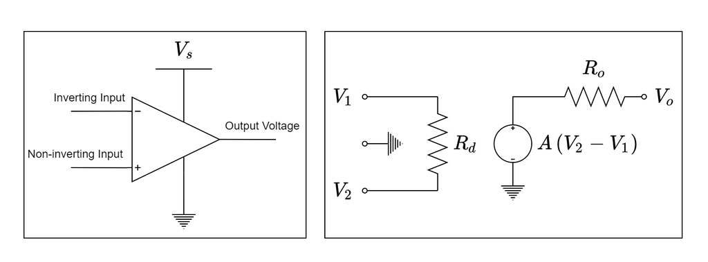

$ V_s $ is the supply voltage that powers the op-amp, $ V_1 $ is the inverting input voltage, $ V_2 $ is non-inverting voltage, $ R_d $ is the input resistance, $ A $ is the op-amp gain, $ R_o $ is the output resistance, and $ V_o $ is the output voltage. With an ideal op-amp, several assumptions are often made.

1. The gain $ A $ of an op amp can be infinite. $ A \rightarrow \infty $

2. There is no offset voltage in the voltage output $ V_o $. If $ V_1 = V_2 $ then $ V_o = 0 V $

This assumption means that the output voltage will not have a zero offset. In practice, there will appear a certain amount of zero offset for an op-amp.

3. The input resistance $ R_d $ is infinite. $ R_d = \infty \Omega $

This assumption means that no current flow between the inputs $ V_1 $ and $ V_2 $. It is as if the input resistance $ R_d $ is completely removed from the circuit, and the inputs $ V_1 $ and $ V_2 $ are left unconnected. In practice, there will be current leakage between the inputs $ V_1 $ and $ V_2 $.

4. The output resistance $ R_o $ is zero. $ R_o = 0 \Omega $

This assumption means that the output resistance $ R_o $ behaves as an ideal wire. There is no loss in the output portion of the op-amp. In practice, there will be an inevitable amount of loss in the internal workings of the op-amp.

5. There are no frequency response limitations or any phase shifts.

This assumption means that the output frequency will be the same as the input frequency, and there will be no phase shift between them. In practice, op-amps have a specific range for which they can respond appropriately. For example, say an input frequency of $ 1 GHz $ is supplied to $ V_1 $. The op-amp may not be able to keep up with this fast frequency, and so it may output a slower frequency to $ V_o $. Even if the op-amp can keep up with the input frequency, the output may be out of sync (i.e., have a phase shift) with the input.

## Op Amp Uses

An op-amp is a very versatile electrical component. It has a wide range of uses and applications. Listed below are some of the more interesting uses of the op-amp in your kit. Its manufacturer provides these uses.

**DC Summing Amplifier**

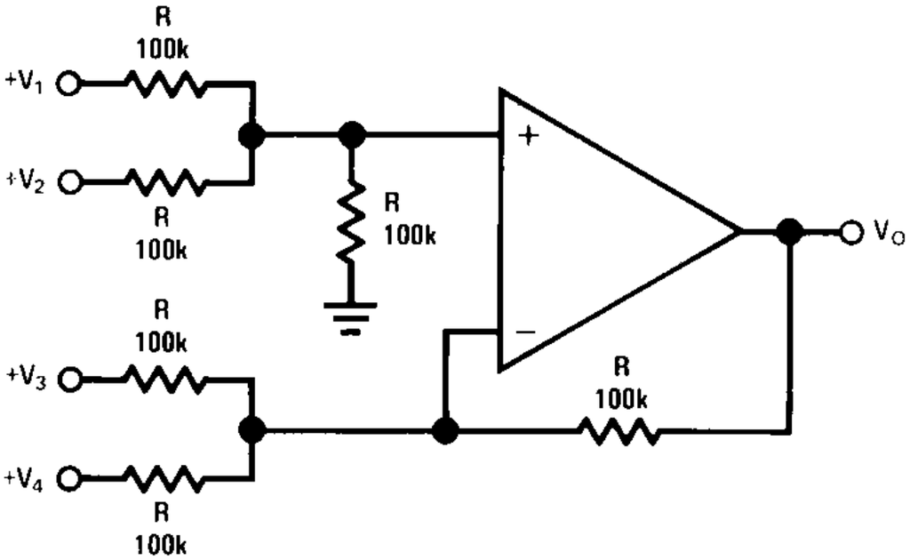

where $ V_o = V_1 + V_2 - V_3 - V_4 $. This is an interesting circuit in that it essentially makes an adding machine. You can adjust the voltages on $ V_1 $, $ V_2 $, $ V_3 $, and $ V_4 $ and the output voltage $ V_o $ will be the sum of the $ V_1 $ and $ V_2 $ minus the sum of $ V_3 $ and $ V_4 $.

**Power Amplifier**

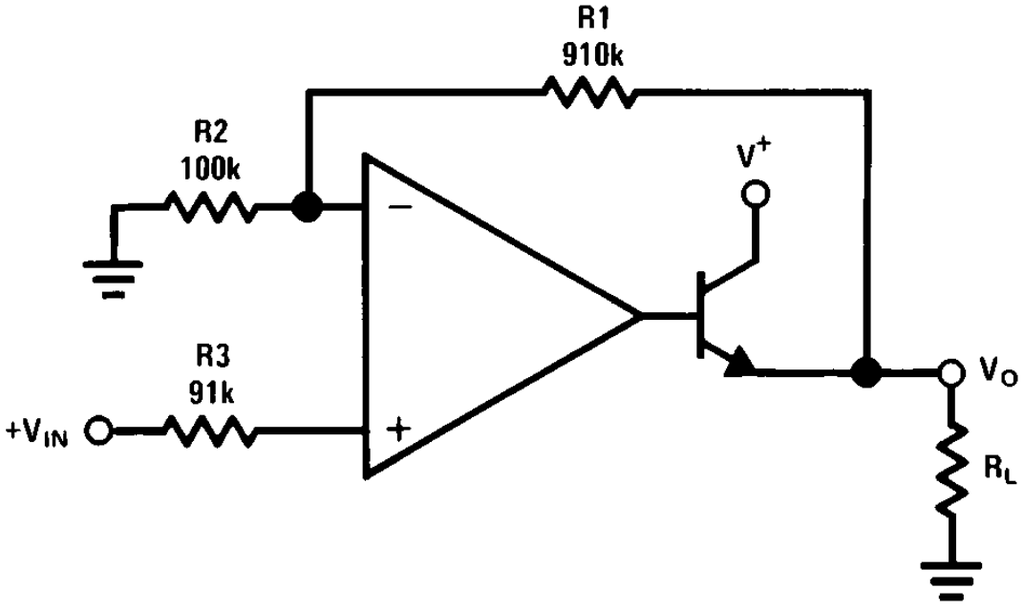

**Fixed Current Sources**

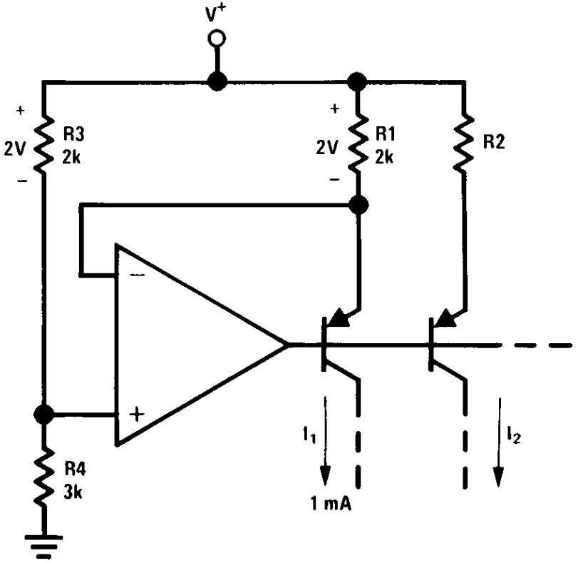

where $ I_2 $ is given by

$$ I_2 = \frac{R_1}{R_2} I_1 $$

**Current Monitor**

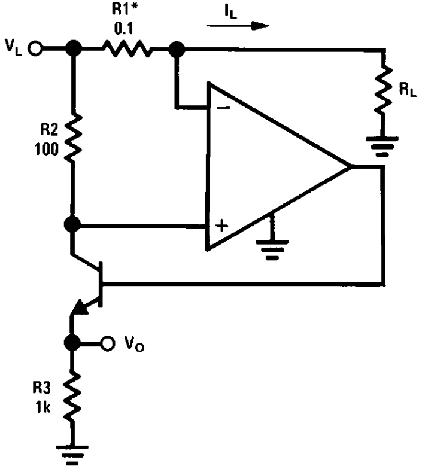

where the output voltage $ V_o $ is given by

$$ V_o = \frac{I_L}{A} V $$

This circuit allows for the current flow $ I_L $ of a load to be monitored by a change in output voltage $ V_o $.

**Voltage Follower**

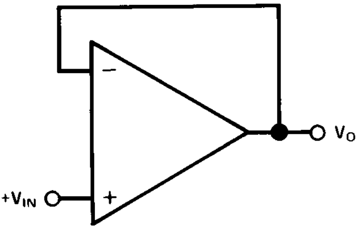

This configuration is probably the simplest of all the op-amp circuits shown in this document. It can be used to isolate one circuit from another. Since the input resistance $ R_d $ is very high (assumed to be $ \infty $), the input voltage $ V_{in} $ and the output voltage $ V_o $ are isolated from one another.

**Pulse Generator 1**

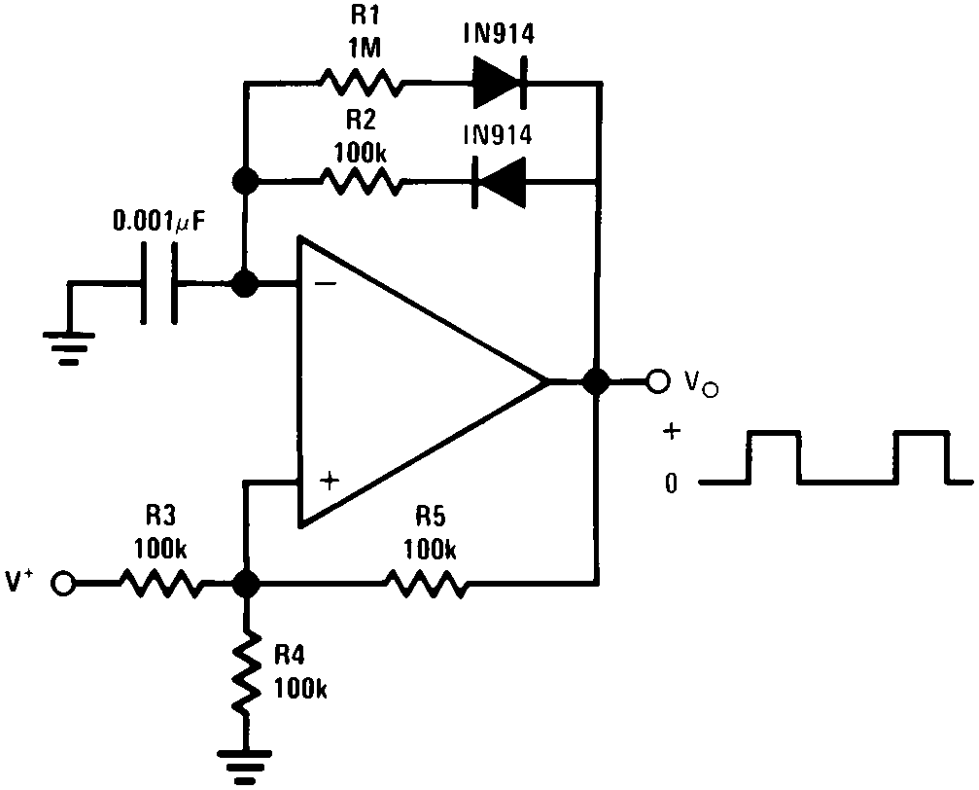

**Pulse Generator 2**

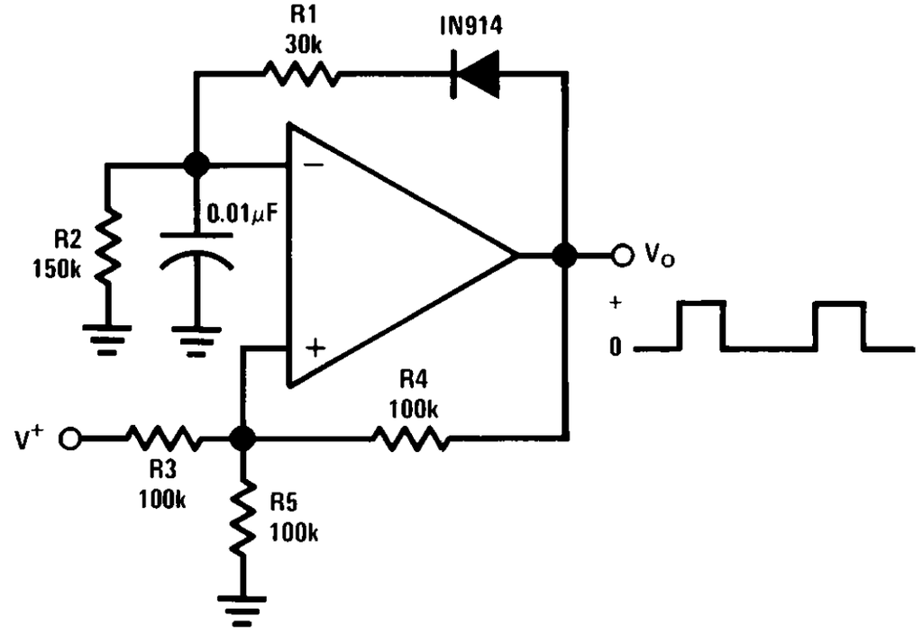

**Squarewave Oscillator**

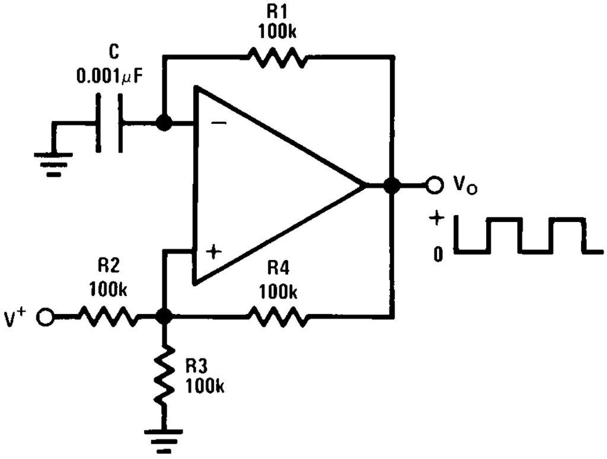

**Voltage Controlled Oscillator (VCO)**

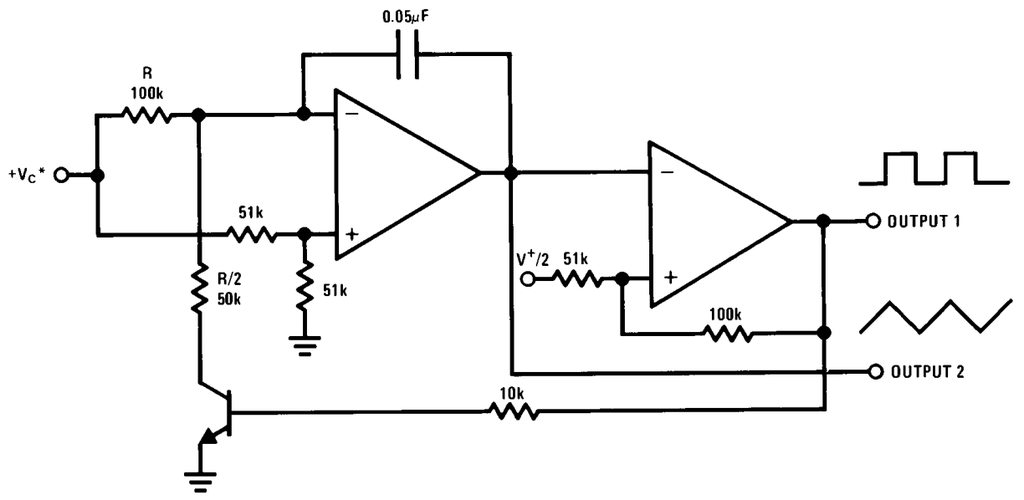

This circuit allows for the two output frequencies to be controlled by the control voltage $ V_c $.

**AC Coupled Inverting Amplifier**

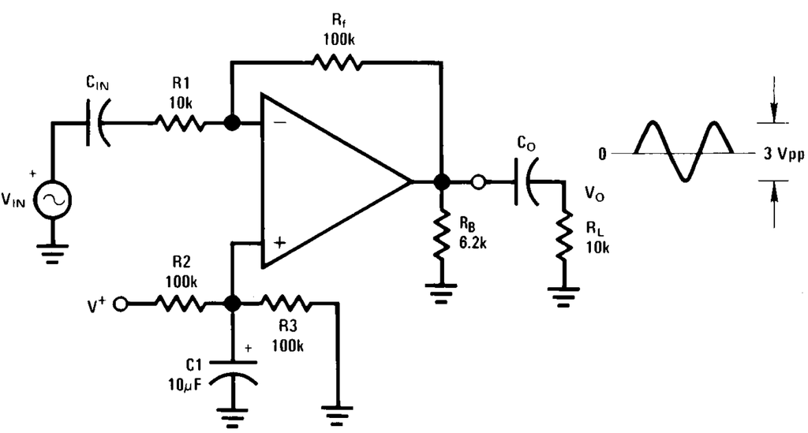

where the gain $ A $ is given by

$$ A = \frac{R_f}{R_1} $$

**AC Coupled Non-inverting Amplifier**

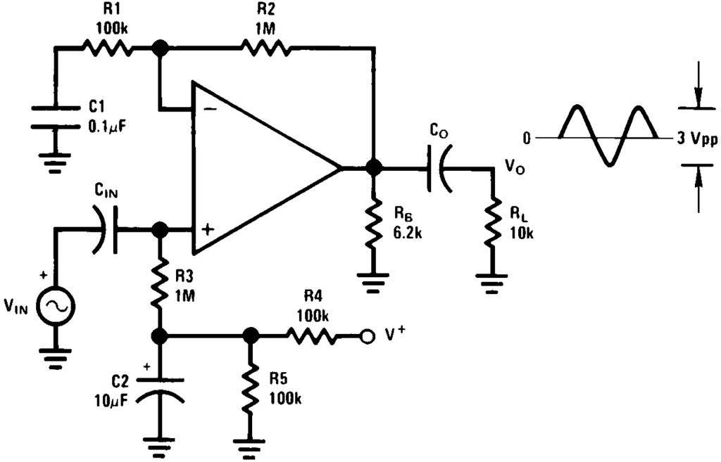

where the gain $ A $ is given by

$$ A = 1 + \frac{R_2}{R_1} $$

**DC Coupled Low-Pass RC Active Filter**

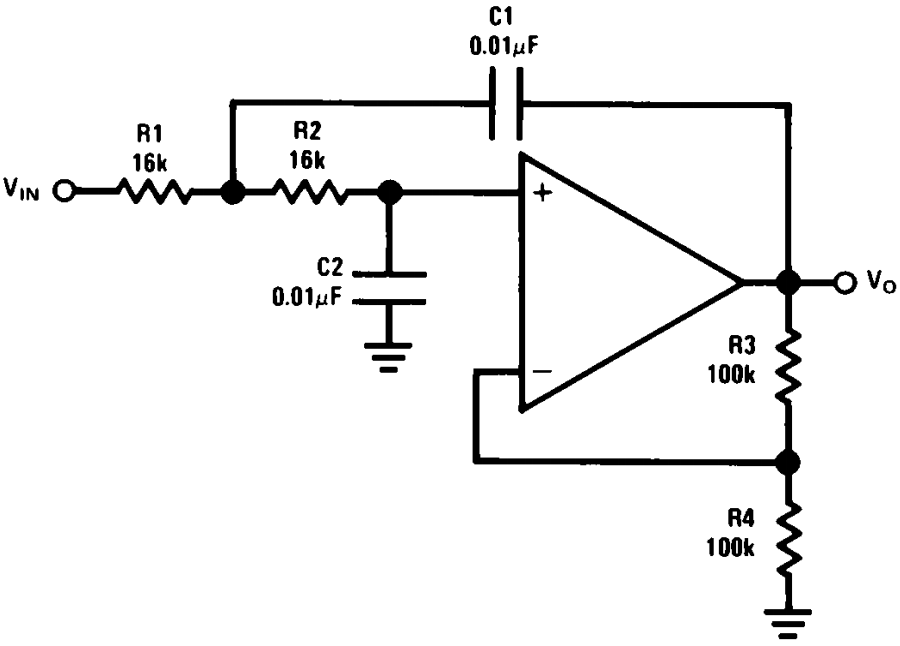

In [system dynamics](https://en.wikipedia.org/wiki/System_dynamics), there are three regions of frequencies that are typically analyzed; low, band, and high frequencies. Low and high frequencies are as the name implies, while the band frequency is the mid-range frequency. There is a systematic method to determine the low, band, and high frequencies, but these methods are beyond this course's scope. This circuit is used to filter out the band and high frequencies from the input voltage and allow the low frequencies to pass through the circuit.

**Bandpass Active Filter**

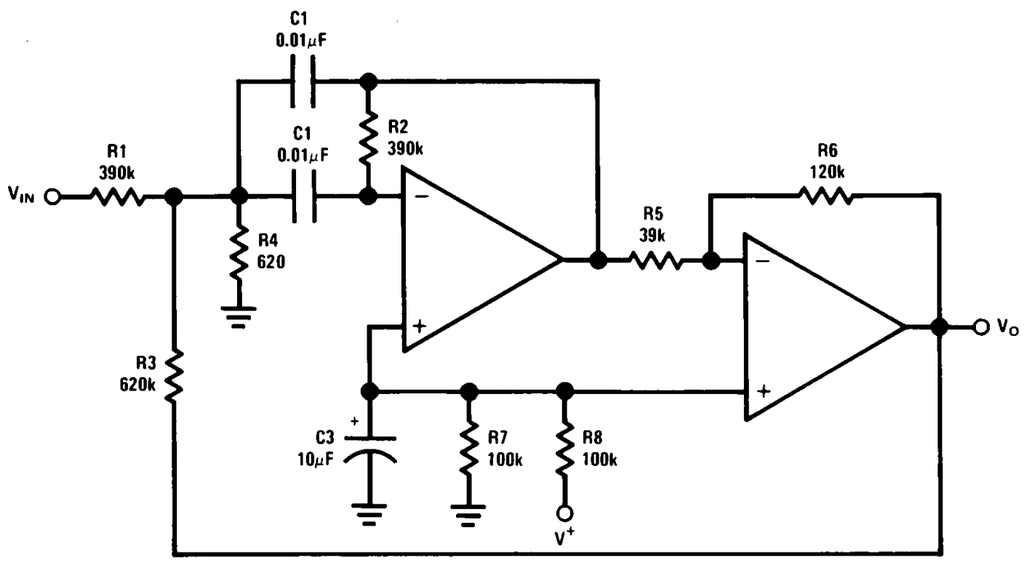

This configuration is similar to the previous circuit, but it filters out the input voltage's low and high frequencies. It allows only the band frequencies to pass through the circuit.

**High Input R, DC Differential Amplifier**

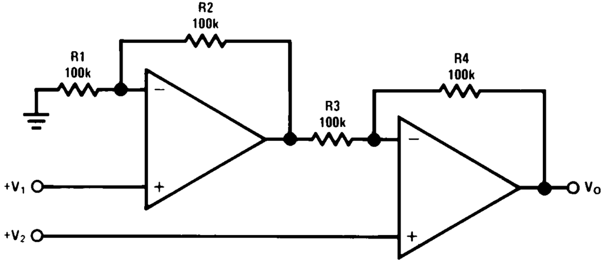

This circuit amplifies the difference between the inputs $ V_1 $ and $ V_2 $. It does so that the inputs are isolated from the output voltage $ V_o $. This isolation is what the "high input R" portion of the name is indicating. The gain $ A $ of the amplifier is given by

$$ A = 1 + \frac{R_4}{R_3} $$

This gain expression assumes that $ \frac{R_1}{R_2} = \frac{R_4}{R_3} $.

**High Input R adjustable-gain DC Instrumentation Amplifier**

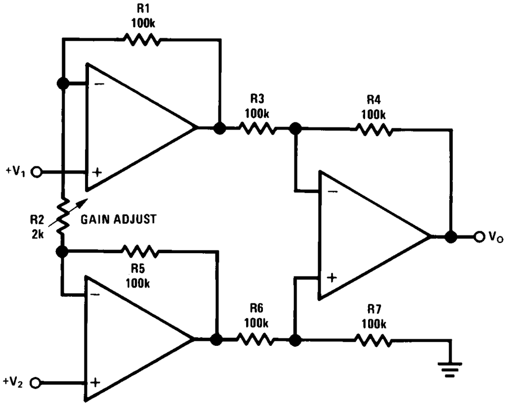

This circuit is similar to the previous circuit, but the gain $ A $ is adjustable. The gain $ A $ is given by

$$ A = 1 + \frac{2 R_1}{R_2} $$

This gain expression assumes that $ R_1 = R_5 $ and $ R_3 = R_4 = R_6 = R_7 $.

**Bridge Current Amplifier**

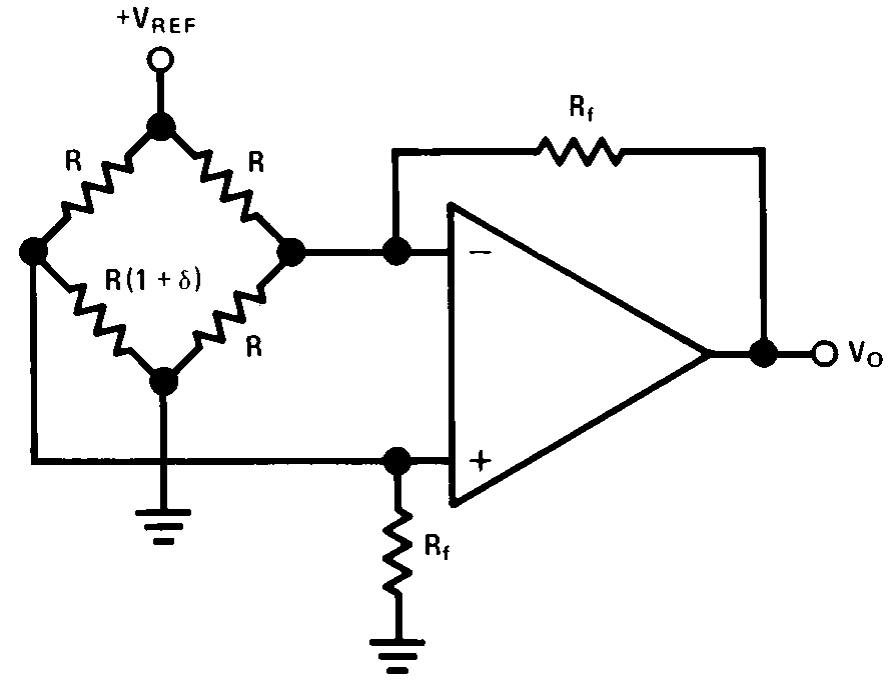

A bridge circuit is the diamond shape circuit shown on the left. It is something that will be discussed later in this course. This circuit amplifies the output of this bridge circuit. The gain $ A $ is given by

$$ A = V_{ref} \frac{\delta}{2} \frac{R_f}{R} $$

**Non-inverting DC Gain**

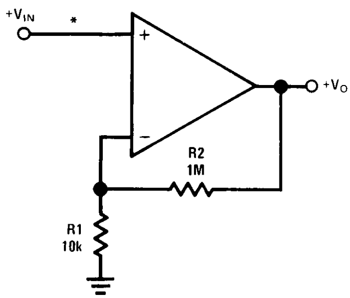

This circuit takes the input voltage $ V_{in} $ and amplifies it by a gain of $ A $. The gain $ A $ is given by

$$ A = 1 + \frac{R_2}{R_1} $$

The output voltage $ V_o $ is then given as

$$ V_o = A V_{in} $$

## Your Op Amp

The op amp in your kit is the [LM358 dual op amp](https://www.ti.com/product/LM358) (found on Digi Key [here](https://www.digikey.com/product-detail/en/texas-instruments/LM358P/296-1395-5-ND/277042)). The component comes as a 8-pin [DIP](https://en.wikipedia.org/wiki/Dual_in-line_package) (dual in-line package). It is noted as a dual op amp because there are two different op amps in the same component. At the time of this writing, the pricing of the LM358 is shown below in Table 1.

[output not shown]

As can be seen from Table 1, the LM358 is relatively cheap. The pinout diagram of the LM358 is shown below in Figure 2.

Figure 2: Op Amp Pin Out

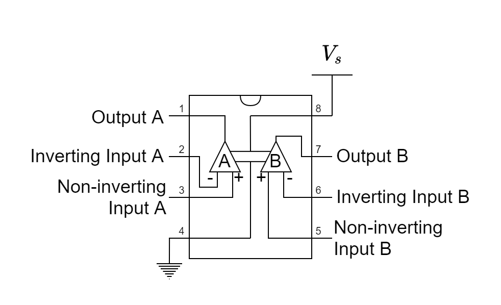

Notice the semicircle on the top side of the pinout diagram. This feature is known as the DIP's notch. This notch indicates the correct orientation of the component. If the notch is at the top, as shown in Figure 2, the pin numbers start at the top left and go counterclockwise. Some DIP components will not have a notch but a small circle located at the component's top-left corner. This small circle is depicted below in Figure 3.

Figure 3: Op Amp Pin Out (alternative orientation indicator)

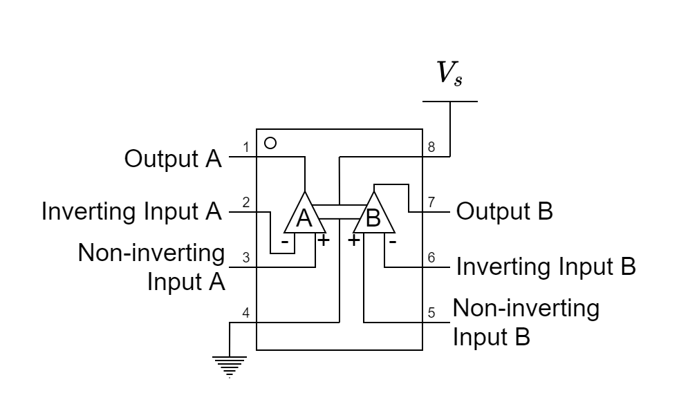

Precaution should be taken to ensure that the component's power supply never becomes reversed in polarity or that the unit is not inadvertently installed backward. Doing so can permanently damage the component. If this occurs, the component will become very hot quickly and likely will be ruined within seconds. To protect against this occurring, always connect the supply voltage $ V_s $ last while using the op-amp.

If the LM358 is used in a non-inverting DC gain configuration, the output response is shown below in Figure 4.

Figure 4: LM358 Non-inverting DC Gain Response

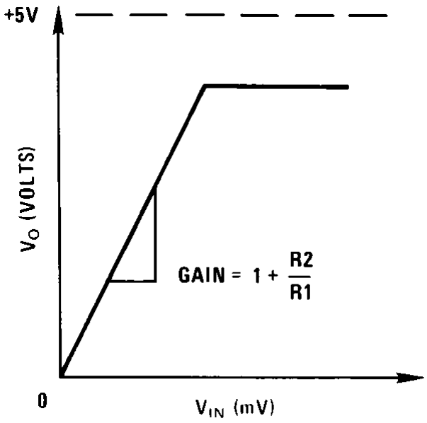

Notice how the line trends linearly up until a certain point. After which the response flat lines. The slope of the first portion of the response is the gain $ A $. The flat line portion is a result of the physical limitation of the device. The actual device is not capable of an infinite amount of gain. At some point, it maxes out. As a general rule of thumb, the maximum output voltage $ V_o $ of an op-amp similar to the LM358 is $ 1.5 V $ less than the op-amp supply voltage $ V_s $.

## Example

**Given and Required:**

For the circuit given below, determine the output voltage $ V_o $.

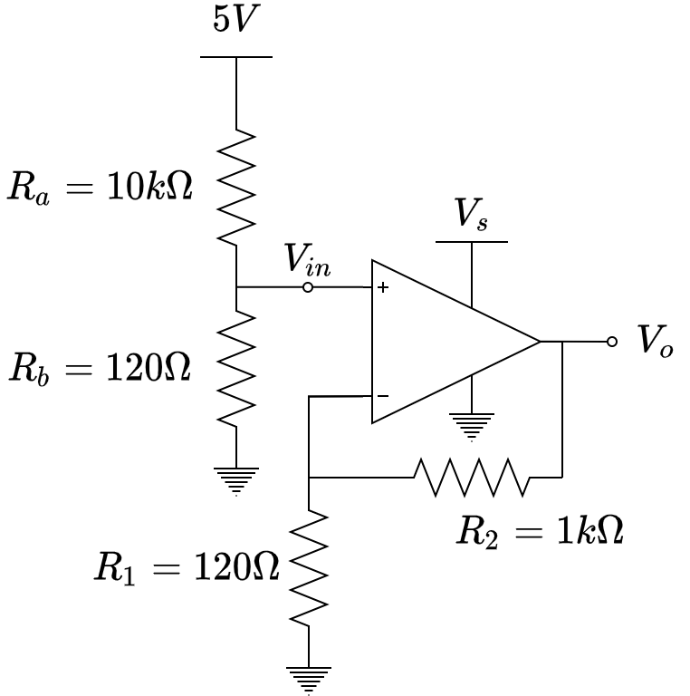

**Solution:**

It may be seen that the left portion of the circuit is a simple voltage divider circuit connected to a non-inverting DC gain amplifying op-amp by inspecting the circuit. The input voltage $ V_{in} $ to the op-amp must first be determined to determine the output voltage $ V_o $. This calculation is shown below using the voltage divider relationship discuss previously in this course.

$$ V_{in} = V_s \frac{R_b}{R_a + R_b} = 5 V \left(\frac{120 \Omega}{120 \Omega + 10, 000 \Omega}\right) \approx 0.05928 V $$

The gain $ A $ of the non-inverting DC gain amplifying op-amp may now be determined.

$$ A = 1 + \frac{R_2}{R_1} = 1 + \frac{1,000 \Omega}{120 \Omega} \approx 9.333 $$

The output voltage $ V_o $ is then

$$ V_o = A V_{in} \approx \left( 9.333 \right) \left( 0.05928 V \right) \approx 0.5533 V $$